# MATH400FinalProject

Melissa Kimble

April 28, 2019

```r
knitr::opts_chunk$set(warning=FALSE, message=FALSE)

LibraryList<-c("ggplot2","mgcv","tidyverse","leaps")
for (TheLibrary in LibraryList)
{
  if(TheLibrary %in% rownames(installed.packages()) == FALSE) install.packages(TheLibrary)
}
library(ggplot2)
library(mgcv)
library(tidyverse)
library(leaps)

FileNameDate<-as.character(format(Sys.Date(), "%Y%m%d"))
TodayDate<-as.character(format(Sys.Date(), "%m-%d-%Y"))

InputDataFolderPath<-"D:/Dropbox/00_Dissertation/01_Data/02_Working/WaterQuality/"
OutputCSVFolderPath<-"D:/Dropbox/00_Dissertation/01_Data/02_Working/WaterQuality"
OutputDataFolderPathPNG<-paste("D:/Dropbox/00_Dissertation/01_Data/04_Figures/Aquaculture/State_DMR/From_Geoff/",FileNameDate,"/",sep="")

TheDirs=c(OutputCSVFolderPath,OutputDataFolderPathPNG)

## checks if the the directories exist, if they don't it creates them.
for (TheDir in TheDirs){
  DirectoryExists<-dir.exists(file.path(TheDir))
  if (DirectoryExists==FALSE) dir.create(file.path(TheDir), recursive = TRUE)
}

## WQ and WL were cleaned and updated (appended new dates) in a separate R script
all_DBFMerge<-read.csv(paste(InputDataFolderPath,"all_DMRBuoyRast_UTM.csv",sep=""))
colnames(all_DBFMerge)[colnames(all_DBFMerge)=="LATITUDE_D"] <- "LATITUDE_DECIMAL"
colnames(all_DBFMerge)[colnames(all_DBFMerge)=="LONGITUDE_"] <- "LONGITUDE_DECIMAL"
all_DBFMerge<-all_DBFMerge[,c("Id","Station","LATITUDE_DECIMAL","LONGITUDE_DECIMAL","Date","YrMo","Easting","Northing","TempC","Sal",
                              "WGOM_m","Type","DMRBuoyID","SMAFishId","SatTempC","StreamDist","Zone","Depth_m")]
all_DBFMerge$DateTime<-as.POSIXlt(all_DBFMerge$Date, tz="GMT", format="%m/%d/%Y %H:%M:%S")
all_DBFMerge$Date2<- strftime(all_DBFMerge$DateTime,"%Y-%m-%d")
all_DBFMerge$Date<-all_DBFMerge$Date2
ColDrop <- c("Date2","DateTime")
all_DBFMerge<-all_DBFMerge[ , !(names(all_DBFMerge) %in% ColDrop)]

all_DBFMerge$Month<-format(as.Date(all_DBFMerge$Date, "%Y-%m-%d"),"%b")
all_DBFMerge$Year<-format(as.Date(all_DBFMerge$Date, "%Y-%m-%d"),"%Y")

Months<-c("Jan","Feb","Mar","Apr","May","Jun","Jul","Aug","Sep","Oct","Nov","Dec")
all_DBFMerge$Month<-factor(all_DBFMerge$Month, levels = Months)

all_DBFMerge_YrMoSub<-all_DBFMerge
#all_DBFMerge_YrMoSub<-all_DBFMerge[(all_DBFMerge$YrMo2>="2014-05" & all_DBFMerge$YrMo2<="2014-11"),]

all_DBFMerge_YrMoSub<-all_DBFMerge_YrMoSub[order(all_DBFMerge_YrMoSub$Date),]
rownames(all_DBFMerge_YrMoSub) <- seq(length=nrow(all_DBFMerge_YrMoSub))
head(all_DBFMerge_YrMoSub)
```

```
##      Id  Station LATITUDE_DECIMAL LONGITUDE_DECIMAL       Date    YrMo
## 1  8827 WQ047.00         43.96960         -69.56357 1990-05-12 1990-05
## 2  9317 WQ018.00         43.97865         -69.57418 1990-05-12 1990-05
## 3  9539 WQ046.00         43.98342         -69.55078 1990-05-12 1990-05
## 4 10006 WQ045.00         43.99381         -69.54169 1990-05-12 1990-05
## 5 10034 WQ020.00         43.99471         -69.55355 1990-05-12 1990-05
## 6 10034 WQ020.00         43.99471         -69.55355 1990-05-12 1990-05
##    Easting Northing TempC Sal WGOM_m   Type DMRBuoyID SMAFishId SatTempC
## 1 454793.2  4868651    10  27  -0.91 Sample 10DMRBuoy    WQ8827       NA
## 2 453949.1  4869662    10  30  -0.10 Sample  1DMRBuoy    WQ9317       NA
## 3 455829.4  4870179    10  26  -0.22 Sample  9DMRBuoy    WQ9539       NA
## 4 456565.9  4871328    11  28  -0.37 Sample  8DMRBuoy   WQ10006       NA
## 5 455615.7  4871434    11  26  -0.10 Sample  3DMRBuoy   WQ10034       NA
## 6 455615.7  4871434    12  27  -0.10 Sample  2DMRBuoy   WQ10034       NA
##   StreamDist Zone Depth_m Month Year
## 1     583.32   WQ    0.25   May 1990
## 2    1208.76   WQ    0.25   May 1990
## 3     141.47   WQ    0.25   May 1990
## 4     223.69   WQ    0.25   May 1990
## 5     316.35   WQ    0.25   May 1990
## 6     316.35   WQ    0.25   May 1990
```

## Background Information

Every data source has characteristic uncertainties. Spatially accurate water temperature estimates aid in identifying suitable aquaculture sites but are challenging to obtain due to limited data availability and because available sources on their own tend to be biased. I am investigating methods for combining data that focus on reducing bias and uncertainty in individual sources. The target products are monthly coastal water temperature and salinity maps that provide a baseline of temperature values for each grid cell.

The Department of Marine Resources collects randomly stratified samples of sea surface temperature and salinity every month since 1990. These samples, however, are only taken along the coast, so values for temperature and salinity for the remainder of the estuary have to be obtained from other sources. The New Meadows (zone WL) and Damarscotta River (zone WQ) have two to three LOBO Buoys each that have been deployed from 2015 - 2018. They collect several oceanographic variables which include sea surface temperature and salinity. The buoys are generally in deeper water near the center of their respective estuaries. The UMaine Satellite Oceanography group routinely converts Landsat-8 into sea surface temperature, which range from 2013 to 2016. The temporal and spatial resolution and the coverage of these datasets vary. Since reflectance obtained from satellite imagery is essentially an average of an area on the ground (for LSAT8, 100-meter), nearshore values are biased because of land influence. Additionally, the DMR samples are susceptible to fresh water inputs and land based run-off. Other datasets used in this study were the Western Gulf of Maine 8-meter bathymetry and euclidean distance from streams derived from the National Hydrography Dataset. Due to the diversity of data types (rasters, vector, and tabular), an 100-meter grid was overlaid and values were averaged within each grid. The sampling points and buoy locations did not overlap grid cells, but the streams, bathymetry, and LSAT8 sea surface temperature values were averaged within any shared grids.

## Exploratory Data Analysis

Water Quality Zones WQ and WL cover different regions, so the below plots were to check if the distributions of Salinity and Temperature were notably different. Zone will be included as a separate variable, because salinity in water quality zone WL has short tails while WQ has a left skew. Temperature for both regions were not notably different. There is high correlation between satellite temperature and buoy locations, which is to be expected because the buoy locations are closer to the center of the estuary, less susceptible to fresh water or land-based inputs.

```r
range(all_DBFMerge$Year[all_DBFMerge$Zone=="WQ"]);range(all_DBFMerge$Year[all_DBFMerge$Zone=="WL"])
```

```
## [1] "1990" "2018"
```

```
## [1] "1990" "2017"
```

```r
range(all_DBFMerge$TempC[all_DBFMerge$Zone=="WQ"]);range(all_DBFMerge$TempC[all_DBFMerge$Zone=="WL"])
```

```
## [1] -4 35
```

```
## [1] -6 33
```

```r
range(all_DBFMerge$Sal[all_DBFMerge$Zone=="WQ"]);range(all_DBFMerge$Sal[all_DBFMerge$Zone=="WL"])
```

```
## [1]  0 35
```

```
## [1]  0 44
```

```r
corrTest<-na.omit(all_DBFMerge)
cor(as.numeric(corrTest$TempC),as.numeric(corrTest$SatTempC))
```

```
## [1] 0.9804376
```

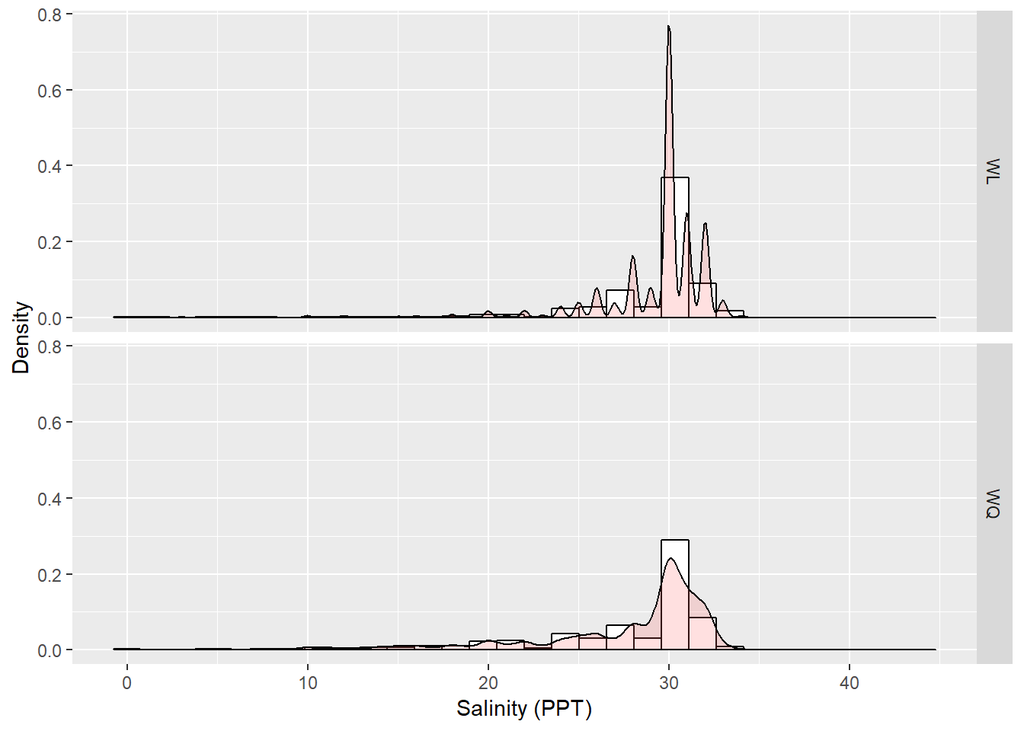

```r
par(mfrow =c(1,2))
# by Zone - WQ or WL
ggplot(all_DBFMerge_YrMoSub,aes(x=as.numeric(Sal))) +
  ylab("Density") +
  xlab("Salinity (PPT)") +
  geom_histogram(aes(y=..density..), colour="black", fill="white")+
  geom_density(alpha=.2, fill="#FF6666") +
  facet_grid(Zone ~ .)
```

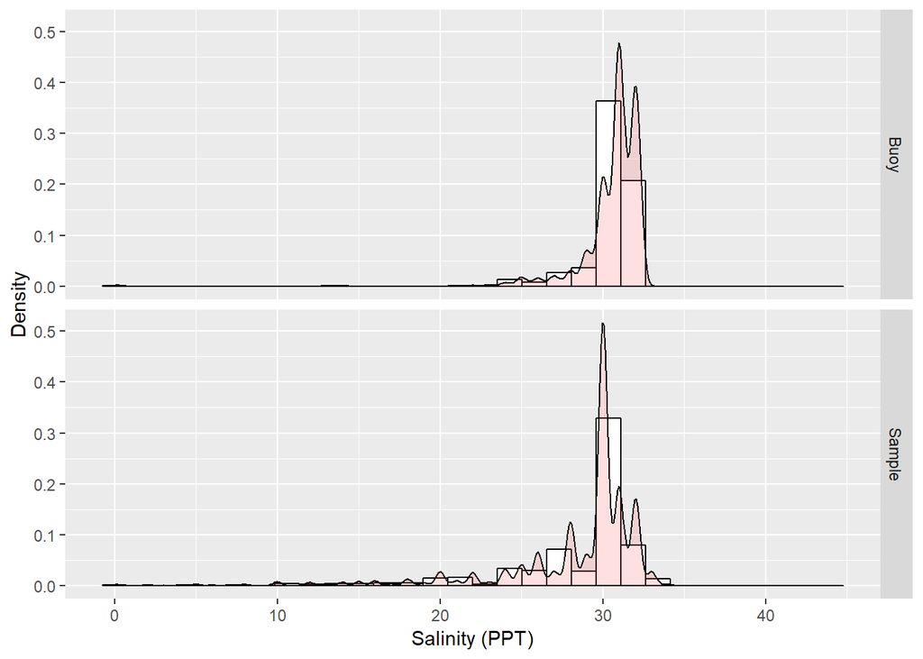

```r
# by Type - Sample or Buoy location
ggplot(all_DBFMerge_YrMoSub,aes(x=as.numeric(Sal))) +
  ylab("Density") +
  xlab("Salinity (PPT)") +
  geom_histogram(aes(y=..density..), colour="black", fill="white")+
  geom_density(alpha=.2, fill="#FF6666") +
  facet_grid(Type ~ .)
```

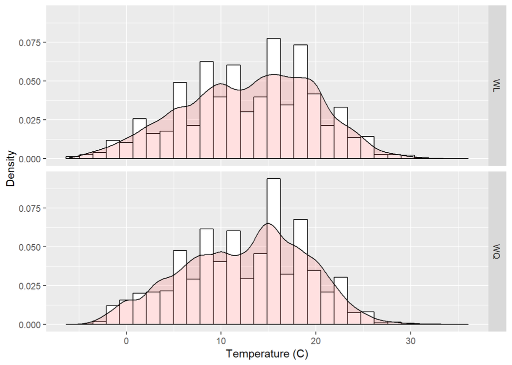

```r
par(mfrow =c(1,2))

# by Zone - WQ or WL
ggplot(all_DBFMerge_YrMoSub,aes(x=as.numeric(TempC))) +
  ylab("Density") +
  xlab("Temperature (C)") +
  geom_histogram(aes(y=..density..), colour="black", fill="white")+
  geom_density(alpha=.2, fill="#FF6666") +
  facet_grid(Zone ~ .)
```

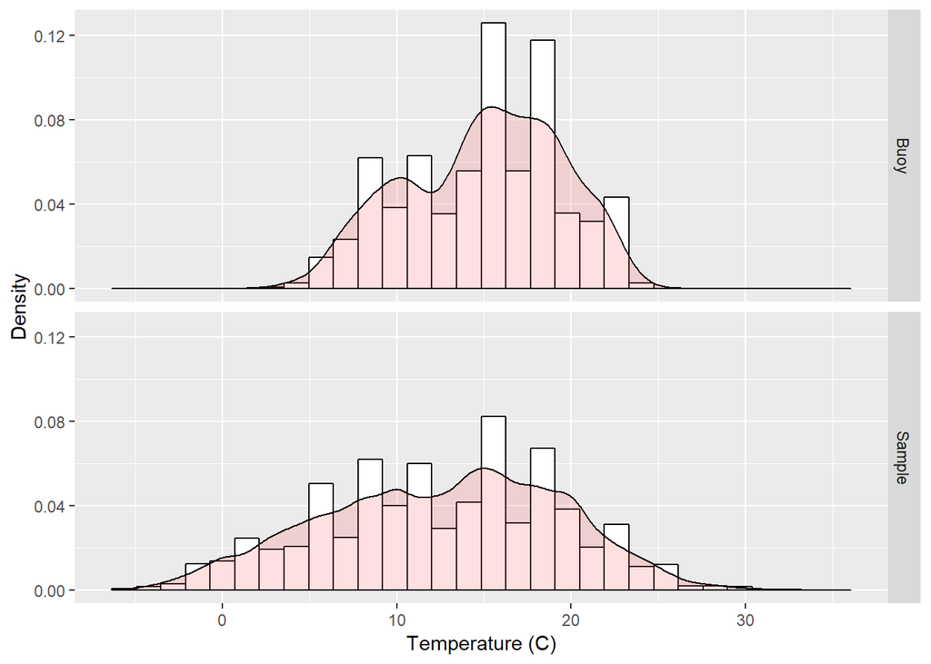

```r
# by Type - Sample or Buoy location
ggplot(all_DBFMerge_YrMoSub,aes(x=as.numeric(TempC))) +
  ylab("Density") +
  xlab("Temperature (C)") +
  geom_histogram(aes(y=..density..), colour="black", fill="white")+
  geom_density(alpha=.2, fill="#FF6666") +
  facet_grid(Type ~ .)
```

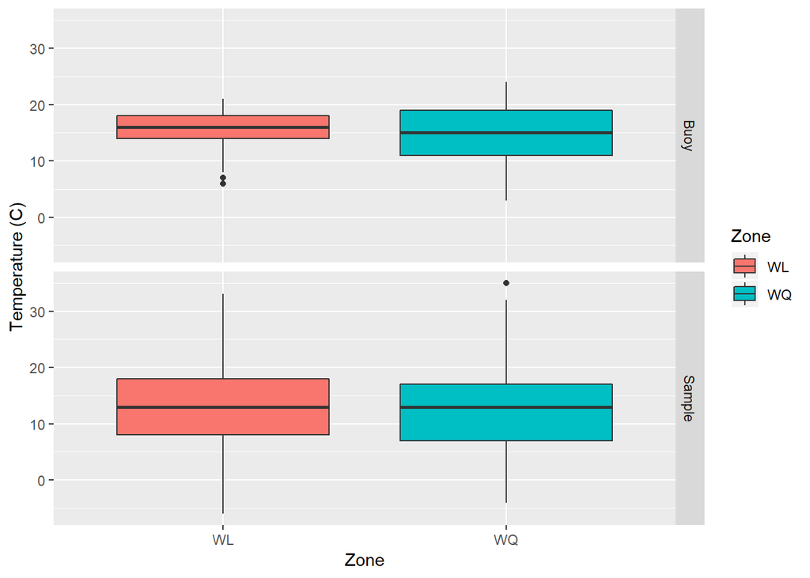

```r
par(mfrow =c(1,2))

# temperature boxplots by zone
ggplot(all_DBFMerge_YrMoSub, aes(x=Zone, y=as.numeric(TempC), fill=Zone)) +
  geom_boxplot() +
  ylab("Temperature (C)") +
  xlab("Zone") +
  facet_grid(Type ~ .)
```

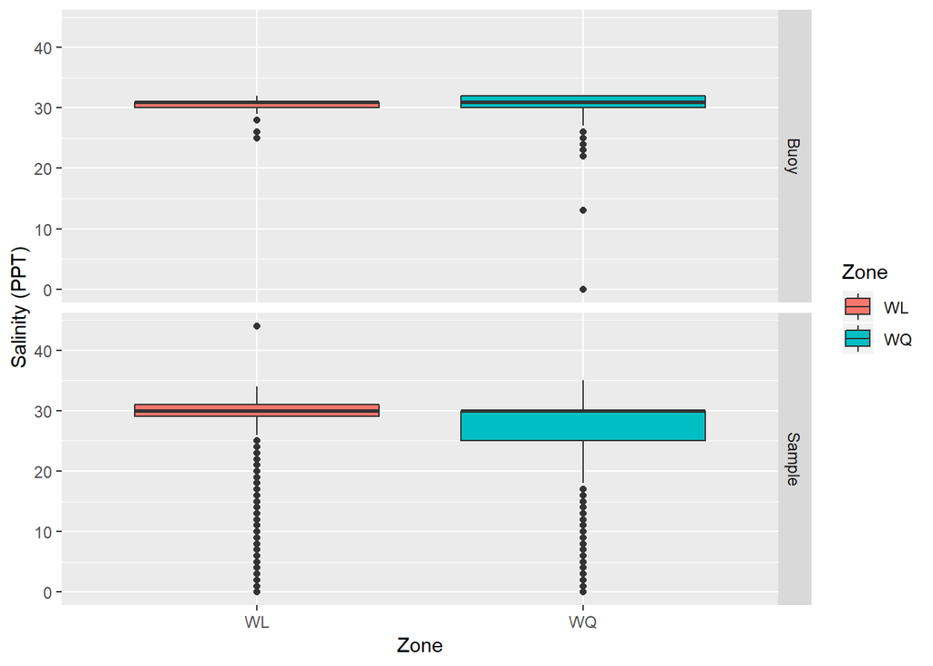

```r
# salinity boxplots by zone
ggplot(all_DBFMerge_YrMoSub, aes(x=Zone, y=as.numeric(Sal), fill=Zone)) +
  geom_boxplot() +
  ylab("Salinity (PPT)") +
  xlab("Zone") +
  facet_grid(Type ~ .)
```

WL and WQ do not not have extreme differences in the relationship between Salinity ~ Temperature. Season, however, will need to be treated separately as a variable (by month) within the shellfish water quality monitoring dataset.

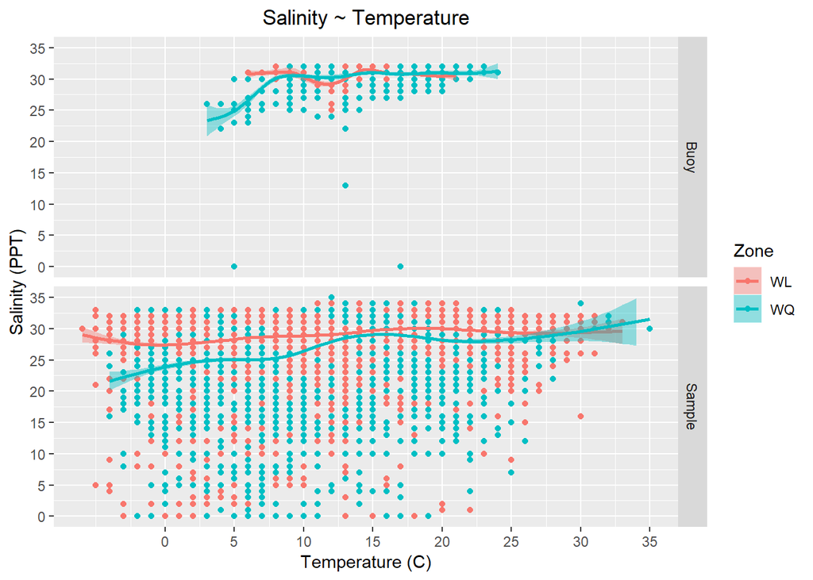

```r
par(mfrow =c(2,2))
# salinity ~ temperature by type & zone
ggplot(data = all_DBFMerge_YrMoSub, aes(x = as.numeric(TempC), y = as.numeric(Sal), fill=Zone, colour=Zone)) +
  geom_point() +
  geom_smooth() +
  xlab("Temperature (C)") +
  scale_x_continuous(breaks=seq(0,35,5)) +
  scale_y_continuous(limits=c(0,35),breaks=seq(0,35,5)) +
  ylab("Salinity (PPT)") +
  ggtitle("Salinity ~ Temperature") +
  theme(plot.title = element_text(hjust=0.5)) +
  facet_grid(Type ~ .)
```

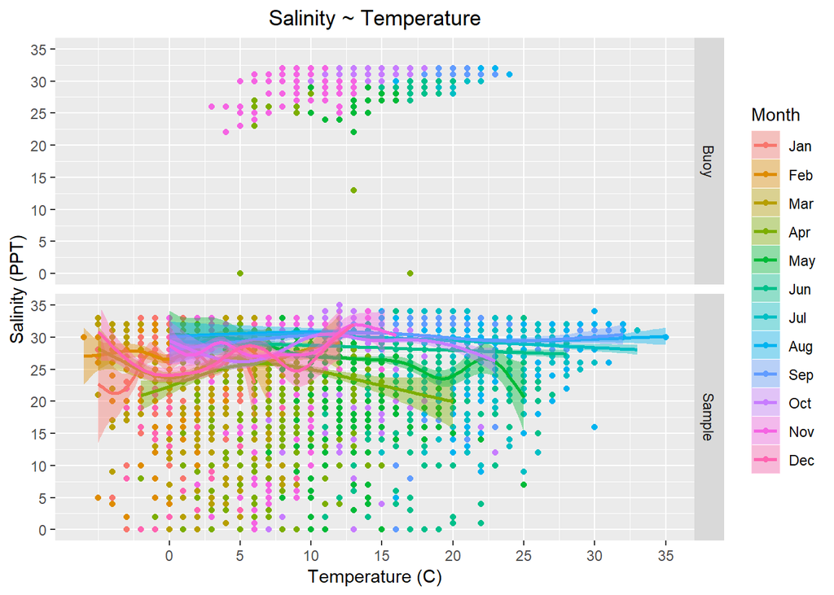

```r
# salinity ~ temperature by zone & month
ggplot(data = all_DBFMerge_YrMoSub, aes(x = as.numeric(TempC), y = as.numeric(Sal), fill=Month, colour=Month)) +
  geom_point() +
  geom_smooth() +
  xlab("Temperature (C)") +
  scale_x_continuous(breaks=seq(0,35,5)) +
  scale_y_continuous(limits=c(0,35),breaks=seq(0,35,5)) +
  ylab("Salinity (PPT)") +
  ggtitle("Salinity ~ Temperature") +
  theme(plot.title = element_text(hjust=0.5)) +
  facet_grid(Type ~ .)
```

```r
set.seed(1)
all_DBFMerge_modsub<-all_DBFMerge[,c("Month","Easting","Northing","TempC","Sal","WGOM_m","Type","StreamDist","Zone","Depth_m")]
rp <- modelr::resample_partition(all_DBFMerge_modsub, c(train = 0.7, test = 0.3))
training_set <- as_tibble(rp$train)
testing_set <- as_tibble(rp$test)

regfit_fwd=regsubsets(Sal~.,data=training_set, nvmax=20, method="forward")
regfit_summ<-summary(regfit_fwd)

MinRSS<-which.min(regfit_summ$rss)
MinRSS
```

```
## [1] 19
```

```r
coef(regfit_fwd,MinRSS)
```

```
##   (Intercept)      MonthFeb      MonthMar      MonthApr      MonthMay
##  1.070308e+03  7.559426e-01 -1.497726e+00 -2.199971e+00 -1.012168e+00
##      MonthJun      MonthJul      MonthAug      MonthSep      MonthOct
## -6.599280e-02  1.101671e+00  1.500546e+00  1.941575e+00  1.634898e+00
##      MonthNov      MonthDec       Easting      Northing         TempC
##  1.847935e-01 -2.698366e-01 -5.540284e-04 -1.653109e-04  5.665312e-02
##        WGOM_m    TypeSample    StreamDist        ZoneWQ       Depth_m
##  5.740643e-02 -1.932318e+00  6.558435e-04  1.477763e+01  1.584720e-01
```

```r
MaxAdjr2<-which.max(regfit_summ$adjr2)
MaxAdjr2
```

```
## [1] 18
```

```r
coef(regfit_fwd,MaxAdjr2)
```

```
##   (Intercept)      MonthFeb      MonthMar      MonthApr      MonthMay
##  1.069744e+03  7.554185e-01 -1.498015e+00 -2.199991e+00 -1.012704e+00
##      MonthJun      MonthJul      MonthAug      MonthSep      MonthOct
## -6.611884e-02  1.100472e+00  1.499015e+00  1.939688e+00  1.632440e+00
##      MonthNov      MonthDec       Easting      Northing         TempC
##  1.834594e-01 -2.690709e-01 -5.532266e-04 -1.652390e-04  5.673844e-02
##        WGOM_m    TypeSample    StreamDist        ZoneWQ
##  5.230868e-02 -2.025876e+00  6.521193e-04  1.475781e+01
```

```r
MinCP<-which.min(regfit_summ$cp)
MinCP
```

```
## [1] 18
```

```r
coef(regfit_fwd,MinCP)
```

```
##   (Intercept)      MonthFeb      MonthMar      MonthApr      MonthMay
##  1.069744e+03  7.554185e-01 -1.498015e+00 -2.199991e+00 -1.012704e+00
##      MonthJun      MonthJul      MonthAug      MonthSep      MonthOct
## -6.611884e-02  1.100472e+00  1.499015e+00  1.939688e+00  1.632440e+00
##      MonthNov      MonthDec       Easting      Northing         TempC
##  1.834594e-01 -2.690709e-01 -5.532266e-04 -1.652390e-04  5.673844e-02
##        WGOM_m    TypeSample    StreamDist        ZoneWQ
##  5.230868e-02 -2.025876e+00  6.521193e-04  1.475781e+01
```

```r
MinBIC<-which.min(regfit_summ$bic)
MinBIC
```

```
## [1] 16
```

```r
coef(regfit_fwd,MinBIC)
```

```
##   (Intercept)      MonthMar      MonthApr      MonthMay      MonthJun
##  1.087389e+03 -2.219652e+00 -2.986983e+00 -1.886740e+00 -1.040192e+00
##      MonthAug      MonthSep      MonthOct      MonthNov      MonthDec
##  4.642776e-01  9.632546e-01  7.376628e-01 -6.125825e-01 -9.701741e-01
##       Easting      Northing         TempC        WGOM_m    TypeSample
## -5.559284e-04 -1.685029e-04  7.577326e-02  5.172896e-02 -2.012609e+00
##    StreamDist        ZoneWQ
##  6.594173e-04  1.487263e+01
```

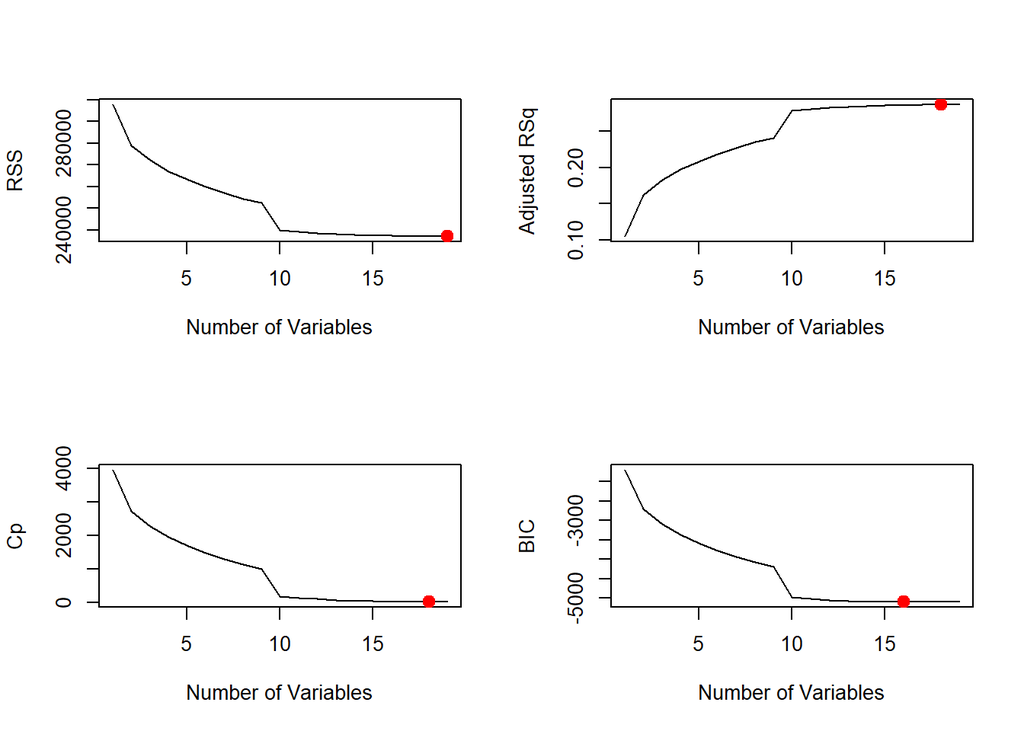

```r
par(mfrow =c(2,2))
plot(regfit_summ$rss, xlab="Number of Variables", ylab="RSS", type="l")
points(MinRSS, regfit_summ$rss[MinRSS], col =" red",cex =2, pch =20)
plot(regfit_summ$adjr2, xlab="Number of Variables", ylab="Adjusted RSq",type="l")
points(MaxAdjr2, regfit_summ$adjr2[MaxAdjr2], col ="red", cex=2, pch =20)
plot(regfit_summ$cp ,xlab ="Number of Variables",ylab="Cp",type="l")
points(MinCP, regfit_summ$cp[MinCP], col="red",cex=2, pch =20)
plot(regfit_summ$bic, xlab="Number of Variables", ylab="BIC", type="l")
points(MinBIC, regfit_summ$bic[MinBIC], col =" red",cex =2, pch =20)
```

```r
## Based on the evaluation plots, model performance stops making gains at 10 coefficients.
coef(regfit_fwd,10) # MonthMar, MonthApr, MonthMay, MonthJun, Easting, Northing, TempC, TypeSample, StreamDist, ZoneWQ
```

```
##   (Intercept)      MonthMar      MonthApr      MonthMay      MonthJun
##  1.089017e+03 -2.145295e+00 -3.025806e+00 -2.083002e+00 -1.415674e+00
##       Easting      Northing         TempC    TypeSample    StreamDist
## -5.521366e-04 -1.693239e-04  1.098934e-01 -1.516607e+00  6.300733e-04
##        ZoneWQ
##  1.481706e+01
```

```r
training_set<-training_set[,c("Month","Easting","Northing","TempC","Sal","Type","StreamDist","Zone")]
testing_set<-testing_set[,c("Month","Easting","Northing","TempC","Sal","Type","StreamDist","Zone")]
```

It was anticipated that R-sq.(adj) = 0.349 Deviance explained = 35.1%

```r
## Base model, no splines.
fit_gam <- mgcv::gam(Sal ~ Month+Easting+Northing+TempC+Type+StreamDist+Zone, data = training_set)
par(mfrow =c(3,3))
mgcv::plot.gam(fit_gam, all.terms=TRUE, se=TRUE)

## TempC
fit_gam1 <- mgcv::gam(Sal ~ Month+Easting+Northing+s(TempC,k=-1,bs="cs")+Type+StreamDist+Zone, data = training_set)
anova(fit_gam,fit_gam1,test="F")
```

```
## Analysis of Deviance Table
##
## Model 1: Sal ~ Month + Easting + Northing + TempC + Type + StreamDist +
##     Zone
## Model 2: Sal ~ Month + Easting + Northing + s(TempC, k = -1, bs = "cs") +
##     Type + StreamDist + Zone
##   Resid. Df Resid. Dev     Df Deviance      F    Pr(>F)
## 1     15502     269095
## 2     15496     264760 5.9615   4335.4 42.565 < 2.2e-16 ***
## ---
## Signif. codes:  0 '***' 0.001 '**' 0.01 '*' 0.05 '.' 0.1 ' ' 1
```

```r
## spline significant on TempC

## StreamDist
fit_gam2<- mgcv::gam(Sal ~ Month+Easting+Northing+s(TempC,k=-1,bs="cs")+Type+s(StreamDist,k=-1,bs="cs")+Zone, data = training_set)
anova(fit_gam1,fit_gam2,test="F")
```

```
## Analysis of Deviance Table
##
## Model 1: Sal ~ Month + Easting + Northing + s(TempC, k = -1, bs = "cs") +
##     Type + StreamDist + Zone
## Model 2: Sal ~ Month + Easting + Northing + s(TempC, k = -1, bs = "cs") +
##     Type + s(StreamDist, k = -1, bs = "cs") + Zone
##   Resid. Df Resid. Dev     Df Deviance      F    Pr(>F)
## 1     15496     264760
## 2     15489     260873 6.9708   3887.2 33.111 < 2.2e-16 ***
## ---
## Signif. codes:  0 '***' 0.001 '**' 0.01 '*' 0.05 '.' 0.1 ' ' 1
```

```r
## spline significant on StreamDist

## Easting
fit_gam3<- mgcv::gam(Sal ~ Month+s(Easting,k=-1,bs="cs")+Northing+s(TempC,k=-1,bs="cs")+Type+s(StreamDist,k=-1,bs="cs")+Zone, data = training_set)
anova(fit_gam2,fit_gam3,test="F")
```

```
## Analysis of Deviance Table
##
## Model 1: Sal ~ Month + Easting + Northing + s(TempC, k = -1, bs = "cs") +
##     Type + s(StreamDist, k = -1, bs = "cs") + Zone
## Model 2: Sal ~ Month + s(Easting, k = -1, bs = "cs") + Northing + s(TempC,
##     k = -1, bs = "cs") + Type + s(StreamDist, k = -1, bs = "cs") +
##     Zone
##   Resid. Df Resid. Dev     Df Deviance      F    Pr(>F)
## 1     15489     260873
## 2     15482     227566 6.6498    33306 340.78 < 2.2e-16 ***
## ---
## Signif. codes:  0 '***' 0.001 '**' 0.01 '*' 0.05 '.' 0.1 ' ' 1
```

```r
## spline significant on Easting

## Northing
fit_gam4<- mgcv::gam(Sal ~ Month+s(Easting,k=-1,bs="cs")+s(Northing,k=-1,bs="cs")+s(TempC,k=-1,bs="cs")+Type+s(StreamDist,k=-1,bs="cs")+Zone, data = training_set)
anova(fit_gam3,fit_gam4,test="F")
```

```
## Analysis of Deviance Table
##
## Model 1: Sal ~ Month + s(Easting, k = -1, bs = "cs") + Northing + s(TempC,
##     k = -1, bs = "cs") + Type + s(StreamDist, k = -1, bs = "cs") +
##     Zone
## Model 2: Sal ~ Month + s(Easting, k = -1, bs = "cs") + s(Northing, k = -1,
##     bs = "cs") + s(TempC, k = -1, bs = "cs") + Type + s(StreamDist,
##     k = -1, bs = "cs") + Zone
##   Resid. Df Resid. Dev     Df Deviance      F    Pr(>F)
## 1     15482     227566
## 2     15468     216157 14.116    11409 57.846 < 2.2e-16 ***
## ---
## Signif. codes:  0 '***' 0.001 '**' 0.01 '*' 0.05 '.' 0.1 ' ' 1
```

```r
## spline significant on Northing
```

[figure not shown]

```r
## Final model
par(mfrow =c(3,3))
mgcv::plot.gam(fit_gam4, all.terms=TRUE, se=TRUE)

summary(fit_gam4)
```

```
##
## Family: gaussian
## Link function: identity
##
## Formula:
## Sal ~ Month + s(Easting, k = -1, bs = "cs") + s(Northing, k = -1,
##     bs = "cs") + s(TempC, k = -1, bs = "cs") + Type + s(StreamDist,
##     k = -1, bs = "cs") + Zone
##
## Parametric coefficients:
##             Estimate Std. Error t value Pr(>|t|)
## (Intercept)  55.6602     5.1240  10.863  < 2e-16 ***
## MonthFeb      0.8889     0.2869   3.098 0.001950 **
## MonthMar     -1.7756     0.2603  -6.821 9.35e-12 ***
## MonthApr     -2.7928     0.2706 -10.321  < 2e-16 ***
## MonthMay     -1.5666     0.2930  -5.347 9.05e-08 ***
## MonthJun     -0.5242     0.3089  -1.697 0.089725 .
## MonthJul      0.6268     0.3153   1.988 0.046786 *
## MonthAug      0.9794     0.3175   3.085 0.002041 **
## MonthSep      1.5381     0.3115   4.937 8.02e-07 ***
## MonthOct      1.1405     0.2962   3.850 0.000118 ***
## MonthNov     -0.3382     0.2799  -1.208 0.226977
## MonthDec     -0.3119     0.2966  -1.052 0.292978
## TypeSample   -0.5977     0.1531  -3.904 9.50e-05 ***
## ZoneWQ      -57.1635    11.0291  -5.183 2.21e-07 ***
## ---
## Signif. codes:  0 '***' 0.001 '**' 0.01 '*' 0.05 '.' 0.1 ' ' 1
##
## Approximate significance of smooth terms:
##                 edf Ref.df     F p-value
## s(Easting)    8.946      9 45.67  <2e-16 ***
## s(Northing)   7.407      9 79.20  <2e-16 ***
## s(TempC)      8.412      9 12.60  <2e-16 ***
## s(StreamDist) 8.933      9 46.34  <2e-16 ***
## ---
## Signif. codes:  0 '***' 0.001 '**' 0.01 '*' 0.05 '.' 0.1 ' ' 1
##
## R-sq.(adj) =  0.349   Deviance explained = 35.1%
## GCV = 14.016  Scale est. = 13.973    n = 15517
```

[figure not shown]

```r
par(mfrow = c(2,2))
```

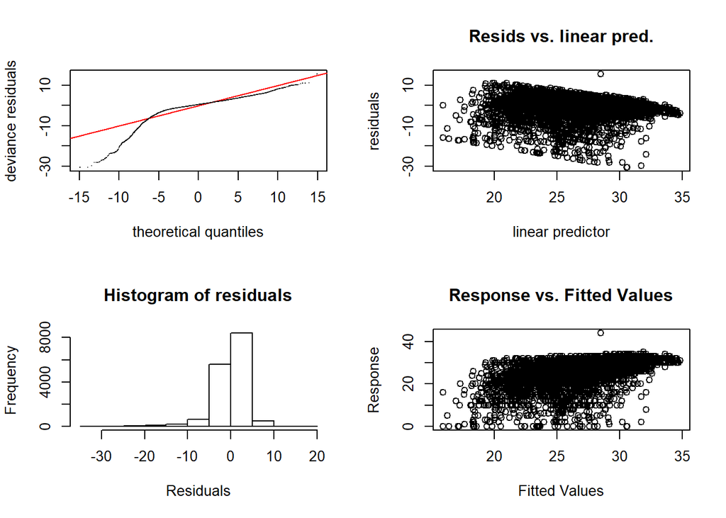

```
##
## Method: GCV   Optimizer: magic
## Smoothing parameter selection converged after 14 iterations.
## The RMS GCV score gradient at convergence was 7.579831e-06 .
## The Hessian was positive definite.
## Model rank =  50 / 50
##
## Basis dimension (k) checking results. Low p-value (k-index<1) may
## indicate that k is too low, especially if edf is close to k'.
##
##                 k'  edf k-index p-value
## s(Easting)    9.00 8.95    0.96   0.005 **
## s(Northing)   9.00 7.41    0.96  <2e-16 ***
## s(TempC)      9.00 8.41    0.99   0.200
## s(StreamDist) 9.00 8.93    0.97   0.010 **
## ---
## Signif. codes:  0 '***' 0.001 '**' 0.01 '*' 0.05 '.' 0.1 ' ' 1
```

```r
gam.check(fit_gam4)
```

## Results & Discussion

When salinity is not available, temperature is often used as a substitute because the relationship between the two are well understood in relatively stable conditions. This substitution becomes problematic in estuarine environments, where there are frequent inputs from fresh water and run-off from nearshore environments. Based on this project, it would seem as though publications that substitute temperature for salinity should not do so in estuarine environments. I was not able to get fresh water inputs available in time for the project due to the complexity of all of the datasets that needed to be synthesized, but included those listed in the introductory of this document. I also want to explore bayesian approaches and need to ensure any testing and training datasets are independent. Spatial datasets tend to be autocorrelated, which would bias diagnostics and model fit. Within this project I was not able to complete a sampling scheme for ensuring sampled datasets are not autocorrelated other than running a Moran’s I on every sampled dataset, which is not efficient or feasible. Right now I am working with using distance from points as a way to sample points, but this works with pairs and will need to be tweaked for the entire dataset to not bottleneck the process. I also explored quadrants, but the issue within th equadrants still remains and simple random stratified sampling did not seem to work as well as needed.

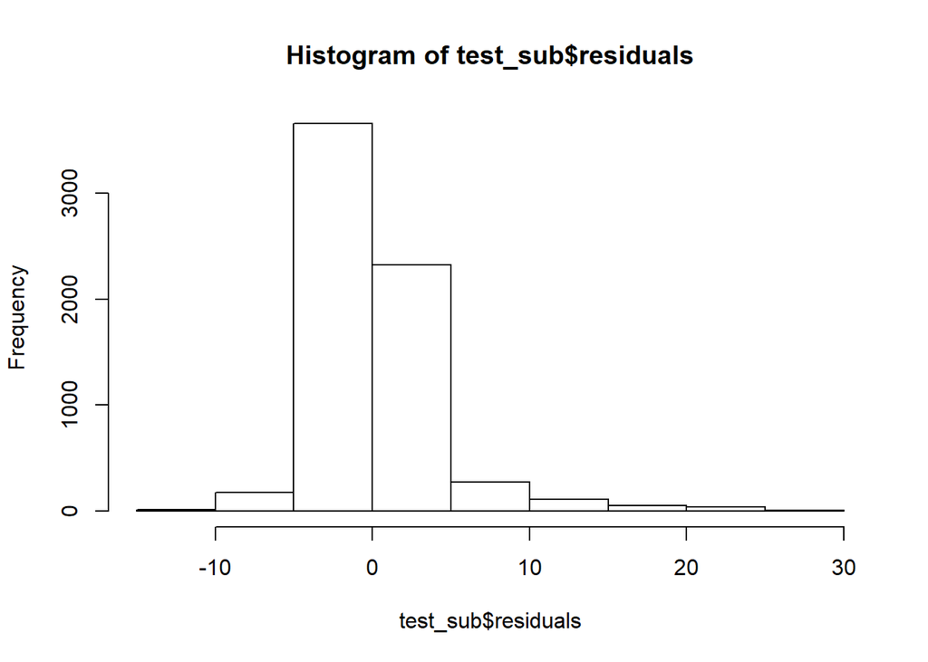

```r
test_sub <- testing_set %>% select(Month, Easting, Northing, TempC, Sal, Type, StreamDist, Zone)
# Report the test error obtained
# https://drsimonj.svbtle.com/visualising-residuals
test_sub$predicted<-predict(fit_gam4, testing_set)
test_sub$residuals<-test_sub$predicted-testing_set$Sal
hist(test_sub$residuals)
```

```r
gam_test_error<-mean((test_sub$residuals)^2)
gam_test_error # 15.97974
```

```
## [1] 15.97974
```

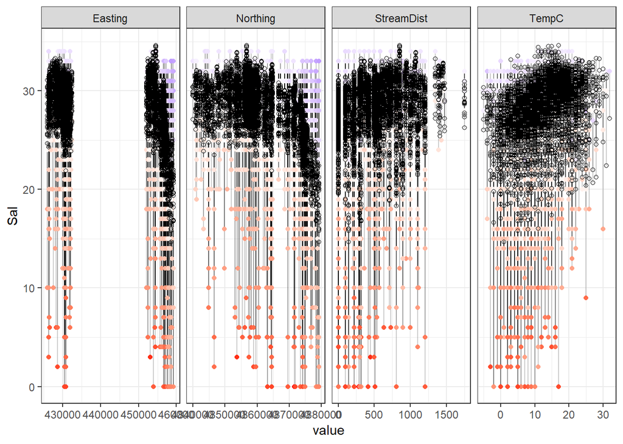

```r
test_sub %>%
  gather(key = "var", value = "value", -Sal, -predicted, -residuals, -Month, -Type, -Zone) %>%  # Get data into shape
  ggplot(aes(x = value, y = Sal)) +  # Note use of `x` here and next line
  geom_segment(aes(xend = value, yend = predicted), alpha = .2) +
  geom_point(aes(color = residuals)) +
  scale_color_gradient2(low = "blue", mid = "white", high = "red") +
  guides(color = FALSE) +
  geom_point(aes(y = predicted), shape = 1) +
  facet_grid(~ var, scales = "free") +  # Split panels here by `var`
  theme_bw()
```

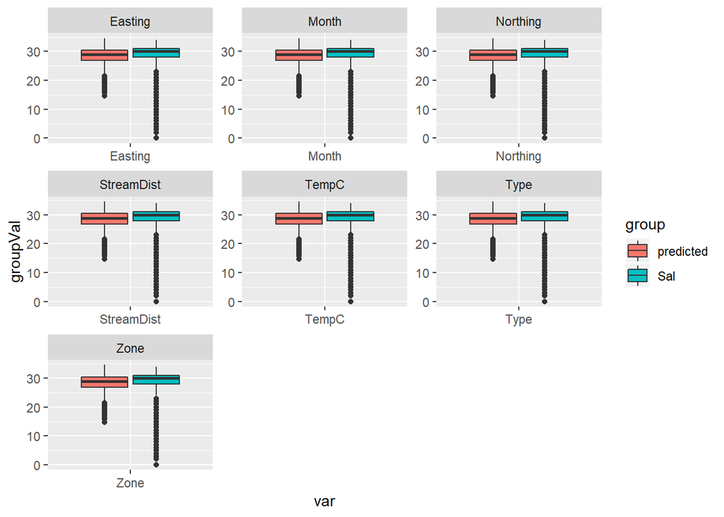

```r
# https://www.r-graph-gallery.com/265-grouped-boxplot-with-ggplot2/
group_melt<-test_sub %>%
  gather(key = "group", value = "groupVal", -Month, -Easting, -Northing, -TempC, -Type, -StreamDist, -Zone, -residuals)
var_melt<-group_melt %>%
  gather(key = "var", value = "value", -group, -groupVal, -residuals)
ggplot(var_melt,aes(x=var, y=groupVal, fill=group)) +
    geom_boxplot() +
    facet_wrap(~var, scale="free")
```